# Predicting Digital Advertising Click-Through-Rate (CTR) with DeepFM Neural Network

[figure not shown]

## Research background

Click-through rate prediction plays a crucial role in any recommendation system and digital advertising. Predicting click-through rates can help advertisers optimise their budget allocation, thereby improving return on investment.

## Research Objectives

Analyse the impact of different unknown factors on ad click-through rates

Build a click-through rate prediction model

## Research Methodology

Traditional machine learning methods have limitations in capturing complex feature interactions behind user behaviour, exhibiting biases towards low-order or high-order intersections, and requiring complex feature engineering. In contrast, DeepFM proposes a novel neural network architecture that combines the advantages of factorisation machines and deep neural networks.

## Data

The data used in this study is sourced from Kaggle's Click-Through Rate Prediction dataset.

## Data Feature Explanation

The dataset consists of 24 features, and their meanings are as follows:

id : personal_id

click : target

hour : format is YYMMDDHH, so 14091123 means 23:00 on Sept. 11, 2014 UTC.

C1 : anonymized categorical variable

banner_pos : showing banner

site domain

site_category

app_id

add_category

device_id

device_ip

device_model

device_type

device_conn_type

C14 ~ C21 : anonymized categorical variables

## About DeepFM

DeepFM (Deep Factorization Machine) is a hybrid model that combines Factorization Machines and Deep Neural Networks to handle machine learning tasks such as recommendation systems and ad prediction.

The core idea of the DeepFM model is to simultaneously utilize Factorization Machines and Deep Neural Networks to learn feature representation and feature interactions, capturing non-linear relationships between features more effectively. The model combines two different components:

1. Factorization Machines: Factorization Machines extend generalized linear models by modeling feature interactions (considering the interaction between two features) at the second order. Factorization Machines can handle sparse and high-dimensional features efficiently and learn implicit factor representations of features. </ul>
2. Deep Neural Networks: Deep Neural Networks are multi-layer neural network models that learn feature representation and feature interactions through multiple hidden layers and non-linear activation functions. Deep Neural Networks can capture more complex feature relationships and have powerful modeling capabilities. </ul> In the DeepFM model, the Factorization Machines component is used to learn low-order feature interactions, while the Deep Neural Networks component is used to learn high-order feature interactions. By adding the outputs of these two components, the model generates the final prediction.

### The DeepFM model has the following characteristics and advantages:

- Ability to capture non-linear feature interactions: The combination of Factorization Machines and Deep Neural Networks enables the model to simultaneously learn low-order and high-order feature interactions, effectively capturing non-linear relationships between features.
- Suitability for sparse and high-dimensional features: The DeepFM model can efficiently handle sparse and high-dimensional features, which are common in scenarios like recommendation systems and ad prediction.
- Better training performance: The inclusion of Deep Neural Networks enhances the expressive power and modeling capabilities of the DeepFM model, enabling it to achieve good training performance on large-scale datasets.

In summary, DeepFM is a hybrid model that combines Factorization Machines and Deep Neural Networks to handle machine learning tasks like recommendation systems and ad prediction. Its design allows it to capture both low-order and high-order feature interactions and adapt to sparse and high-dimensional features, thereby improving predictive performance.

### DeepFM Structure

[figure not shown]

```python
import os
import numpy as np
import pandas as pd
import seaborn as sns
import matplotlib.pyplot as plt
import random
import gc

plt.style.use('ggplot')

import warnings as w
w.filterwarnings(action='ignore')
pd.set_option('display.max_columns',None)
```

### Convert the data to the suitable datatypes

### The training dataset is quite large, so it is necessary to sample the data.

```python
dtype={'id': np.dtype(int),
    'click': np.dtype(int),
    'hour': np.str,
    'C1': np.dtype(str),
    'banner_pos': np.dtype(str),
    'site_id': np.dtype(str),
    'site_domain': np.dtype(str),
    'site_category': np.dtype(str),
    'app_id': np.dtype(str),
    'app_domain': np.dtype(str),
    'app_category': np.dtype(str),
    'device_id': np.dtype(str),
    'device_ip': np.dtype(str),
    'device_model': np.dtype(str),
    'device_type': np.dtype(str),
    'device_conn_type': np.dtype(str),
    'C14': np.dtype(str),
    'C15': np.dtype(str),
    'C16': np.dtype(str),
    'C17': np.dtype(str),
    'C18': np.dtype(str),
    'C19': np.dtype(str),
    'C20': np.dtype(str),
    'C21':np.dtype(str)
      }
num_records = 40428967
sample_size = 5000000
skip_values = sorted(random.sample(range(1,num_records), num_records - sample_size))
parse_date = lambda val : pd.datetime.strptime(val, '%y%m%d%H')
```

```python
train = pd.read_csv("../input/avazu-ctr-prediction/train.gz", parse_dates=['hour'], date_parser=parse_date, dtype=dtype, skiprows=skip_values)
test = pd.read_csv('../input/avazu-ctr-prediction/test.gz')
submission = pd.read_csv('../input/avazu-ctr-prediction/sampleSubmission.gz')
print('Train dataset:',train.shape)
print('Test dataset:',test.shape)
print('Submission:',submission.shape)
```

```
Train dataset: (5000000, 24)
Test dataset: (4577464, 23)
Submission: (4577464, 2)
```

### Review the training and testing datasets

```python
train.head()
```

|  | id | click | hour | C1 | banner_pos | site_id | site_domain | site_category | app_id | app_domain | app_category | device_id | device_ip | device_model | device_type | device_conn_type | C14 | C15 | C16 | C17 | C18 | C19 | C20 | C21 |
| --- | --- | --- | --- | --- | --- | --- | --- | --- | --- | --- | --- | --- | --- | --- | --- | --- | --- | --- | --- | --- | --- | --- | --- | --- |
| 0 | 10000371904215119486 | 0 | 2014-10-21 | 1005 | 0 | 1fbe01fe | f3845767 | 28905ebd | ecad2386 | 7801e8d9 | 07d7df22 | a99f214a | b3cf8def | 8a4875bd | 1 | 0 | 15704 | 320 | 50 | 1722 | 0 | 35 | 100084 | 79 |
| 1 | 10000720757801103869 | 0 | 2014-10-21 | 1005 | 0 | d6137915 | bb1ef334 | f028772b | ecad2386 | 7801e8d9 | 07d7df22 | a99f214a | 05241af0 | 8a4875bd | 1 | 0 | 16920 | 320 | 50 | 1899 | 0 | 431 | 100077 | 117 |
| 2 | 10001264480619467364 | 0 | 2014-10-21 | 1002 | 0 | 84c7ba46 | c4e18dd6 | 50e219e0 | ecad2386 | 7801e8d9 | 07d7df22 | c357dbff | f1ac7184 | 373ecbe6 | 0 | 0 | 21689 | 320 | 50 | 2496 | 3 | 167 | 100191 | 23 |
| 3 | 10003539039235338011 | 0 | 2014-10-21 | 1005 | 0 | 1fbe01fe | f3845767 | 28905ebd | ecad2386 | 7801e8d9 | 07d7df22 | a99f214a | a4f47b2e | 8a4875bd | 1 | 0 | 15699 | 320 | 50 | 1722 | 0 | 35 | 100084 | 79 |
| 4 | 10004181428767727519 | 0 | 2014-10-21 | 1005 | 1 | 0c2fe9d6 | 27e3c518 | 28905ebd | ecad2386 | 7801e8d9 | 07d7df22 | a99f214a | b7a69808 | 158e4944 | 1 | 0 | 6558 | 320 | 50 | 571 | 2 | 39 | -1 | 32 |

```python
test.head()
```

|  | id | hour | C1 | banner_pos | site_id | site_domain | site_category | app_id | app_domain | app_category | device_id | device_ip | device_model | device_type | device_conn_type | C14 | C15 | C16 | C17 | C18 | C19 | C20 | C21 |
| --- | --- | --- | --- | --- | --- | --- | --- | --- | --- | --- | --- | --- | --- | --- | --- | --- | --- | --- | --- | --- | --- | --- | --- |
| 0 | 1.000017e+19 | 14103100 | 1005 | 0 | 235ba823 | f6ebf28e | f028772b | ecad2386 | 7801e8d9 | 07d7df22 | a99f214a | 69f45779 | 0eb711ec | 1 | 0 | 8330 | 320 | 50 | 761 | 3 | 175 | 100075 | 23 |
| 1 | 1.000018e+19 | 14103100 | 1005 | 0 | 1fbe01fe | f3845767 | 28905ebd | ecad2386 | 7801e8d9 | 07d7df22 | a99f214a | e8d44657 | ecb851b2 | 1 | 0 | 22676 | 320 | 50 | 2616 | 0 | 35 | 100083 | 51 |
| 2 | 1.000055e+19 | 14103100 | 1005 | 0 | 1fbe01fe | f3845767 | 28905ebd | ecad2386 | 7801e8d9 | 07d7df22 | a99f214a | 10fb085b | 1f0bc64f | 1 | 0 | 22676 | 320 | 50 | 2616 | 0 | 35 | 100083 | 51 |
| 3 | 1.000109e+19 | 14103100 | 1005 | 0 | 85f751fd | c4e18dd6 | 50e219e0 | 51cedd4e | aefc06bd | 0f2161f8 | a99f214a | 422d257a | 542422a7 | 1 | 0 | 18648 | 320 | 50 | 1092 | 3 | 809 | 100156 | 61 |
| 4 | 1.000138e+19 | 14103100 | 1005 | 0 | 85f751fd | c4e18dd6 | 50e219e0 | 9c13b419 | 2347f47a | f95efa07 | a99f214a | 078c6b38 | 1f0bc64f | 1 | 0 | 23160 | 320 | 50 | 2667 | 0 | 47 | -1 | 221 |

### Checking null values

No null values

```python
train.isna().sum()
```

```
id                  0
click               0
hour                0
C1                  0
banner_pos          0
site_id             0
site_domain         0
site_category       0
app_id              0
app_domain          0
app_category        0
device_id           0
device_ip           0
device_model        0
device_type         0
device_conn_type    0
C14                 0
C15                 0
C16                 0
C17                 0
C18                 0
C19                 0
C20                 0
C21                 0
dtype: int64
```

### Checking the distribution of the target feature (Clicks)

0: no click; 1: clicked  
The distribution for Clicks is imbalanced

```
0    4151607
1     848393
Name: click, dtype: int64
```

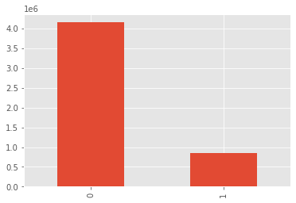

```python
train.click.value_counts().plot(kind='bar')
print(train.click.value_counts())
```

### Checking the distribution of ad ranks

The assumption is that ads that rank higher have a higher chance of being seen by users, which can potentially impact the click-through rate.

Most ads are ranked in the first position.

```python
train.banner_pos.value_counts()
```

```
0    3599809
1    1391234
7       5458
2       1642
4        953
5        651
3        253
Name: banner_pos, dtype: int64
```

### Ad rank and click-through-rate

The chart shows that these two features do not have relationship

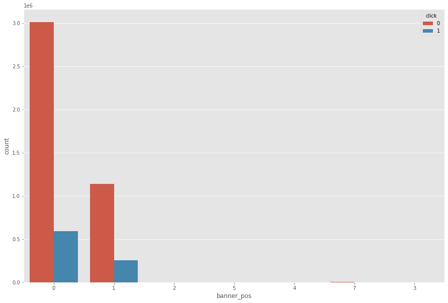

```python
plt.figure(figsize=(15,10))
sns.countplot(x='banner_pos',hue='click',data=train)
```

### The distribution of time and clicks

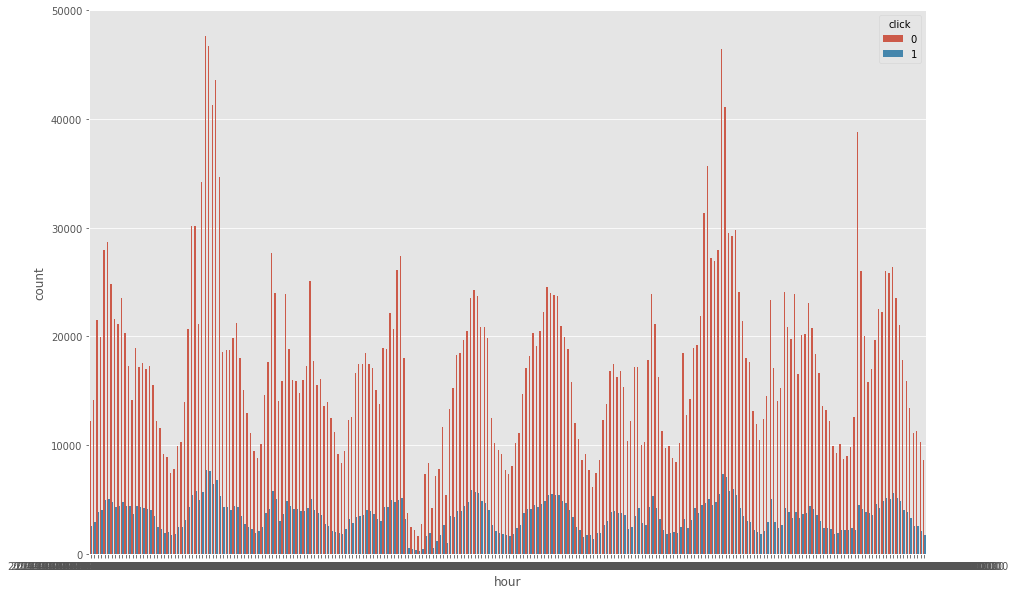

```python
plt.figure(figsize=(15,10))
sns.countplot(x='hour',hue='click',data=train)
```

### Hourly anaysis on clicks

Segmented a day's data to check the click changes by hours.

We found that the clicks fluturate over time.

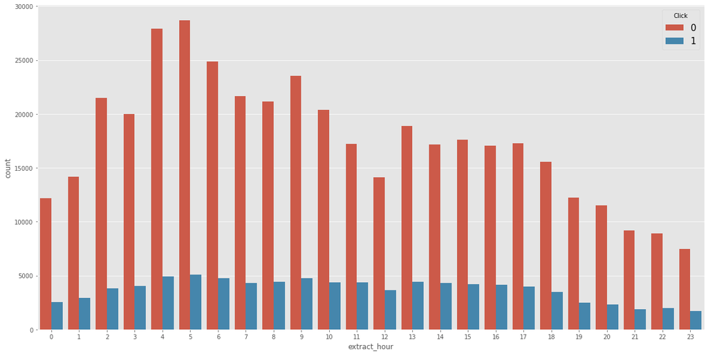

```python
ex_data = train[train['hour'] < '2014-10-22']
ex_data['extract_hour'] = ex_data['hour'].dt.hour
plt.figure(figsize=(20, 10))
sns.countplot(x='extract_hour',hue='click',data=ex_data)
plt.legend(title='Click', loc='upper right', prop={'size': 15})
plt.show()
```

```python
train.set_index('hour',inplace=True)
```

```python
test.set_index('hour',inplace=True)
```

### Dense features

- C14 ~ c21

```python
!pip install deepctr_torch
```

## Preprocessomg the data and select feature columns for training models

```python
import torch
from deepctr_torch.inputs import SparseFeat, DenseFeat, get_feature_names
from deepctr_torch.models import *
```

```python
data = train
```

```python
sparse_features = train.iloc[::,2:14].columns.values.tolist()
dense_features = train.iloc[::,15:].columns.values.tolist()
sparse_features.append('id')
target = ['click']
```

```python
test.head()
```

| hour | id | C1 | banner_pos | site_id | site_domain | site_category | app_id | app_domain | app_category | device_id | device_ip | device_model | device_type | device_conn_type | C14 | C15 | C16 | C17 | C18 | C19 | C20 | C21 |
| --- | --- | --- | --- | --- | --- | --- | --- | --- | --- | --- | --- | --- | --- | --- | --- | --- | --- | --- | --- | --- | --- | --- |
| 14103100 | 1.000017e+19 | 1005 | 0 | 235ba823 | f6ebf28e | f028772b | ecad2386 | 7801e8d9 | 07d7df22 | a99f214a | 69f45779 | 0eb711ec | 1 | 0 | 8330 | 320 | 50 | 761 | 3 | 175 | 100075 | 23 |
| 14103100 | 1.000018e+19 | 1005 | 0 | 1fbe01fe | f3845767 | 28905ebd | ecad2386 | 7801e8d9 | 07d7df22 | a99f214a | e8d44657 | ecb851b2 | 1 | 0 | 22676 | 320 | 50 | 2616 | 0 | 35 | 100083 | 51 |
| 14103100 | 1.000055e+19 | 1005 | 0 | 1fbe01fe | f3845767 | 28905ebd | ecad2386 | 7801e8d9 | 07d7df22 | a99f214a | 10fb085b | 1f0bc64f | 1 | 0 | 22676 | 320 | 50 | 2616 | 0 | 35 | 100083 | 51 |
| 14103100 | 1.000109e+19 | 1005 | 0 | 85f751fd | c4e18dd6 | 50e219e0 | 51cedd4e | aefc06bd | 0f2161f8 | a99f214a | 422d257a | 542422a7 | 1 | 0 | 18648 | 320 | 50 | 1092 | 3 | 809 | 100156 | 61 |
| 14103100 | 1.000138e+19 | 1005 | 0 | 85f751fd | c4e18dd6 | 50e219e0 | 9c13b419 | 2347f47a | f95efa07 | a99f214a | 078c6b38 | 1f0bc64f | 1 | 0 | 23160 | 320 | 50 | 2667 | 0 | 47 | -1 | 221 |

## Specifying the dense and sparse features

```python
test_sparse_features = test.iloc[::,0:14].columns.values.tolist()
test_dense_features = test.iloc[::,14:].columns.values.tolist()
```

```python
from sklearn.preprocessing import MinMaxScaler,LabelEncoder
scaler = MinMaxScaler(feature_range=(0,1))
encoder = LabelEncoder()
```

```python
for f in sparse_features:
    data[f] = encoder.fit_transform(data[f])
data[dense_features] = scaler.fit_transform(data[dense_features])
```

```python
for f in test_sparse_features:
    test[f] = encoder.fit_transform(test[f])
test[dense_features] = scaler.fit_transform(test[test_dense_features])
```

### Constructing a set of feature columns based on the characteristics of sparse features and dense features:

- For sparse features, use SparseFeat(f, data[f].nunique()) to create a sparse feature column, where f represents the feature name.
- For dense features, use DenseFeat(f, 1) to create a dense feature column.

These feature columns will be used for constructing subsequent machine learning models to describe how the models should handle different types of features. The sparse feature columns and dense feature columns will be used together as input features for the model.

```python
fixlen_feature_columns = [SparseFeat(f,data[f].nunique())
                          for f in sparse_features] + [DenseFeat(f,1,)
                                                         for f in dense_features]
```

```python
fixlen_feature_columns[1]
```

```
SparseFeat(name='banner_pos', vocabulary_size=7, embedding_dim=4, use_hash=False, dtype='int32', embedding_name='banner_pos', group_name='default_group')
```

## Defining the DNN model and the linear model's feature columns.

```python
dnn_feature_columns = fixlen_feature_columns
linear_feature_columns = fixlen_feature_columns
```

```python
feature_names = get_feature_names(linear_feature_columns + dnn_feature_columns)
feature_names
```

```
['C1',
 'banner_pos',
 'site_id',
 'site_domain',
 'site_category',
 'app_id',
 'app_domain',
 'app_category',
 'device_id',
 'device_ip',
 'device_model',
 'device_type',
 'id',
 'C14',
 'C15',
 'C16',
 'C17',
 'C18',
 'C19',
 'C20',
 'C21']
```

```python
train_model_input = {name: data[name]for name in feature_names}
```

```python
test_model_input = {name: test[name] for name in feature_names}
```

Checking if the system support CUBA (GPU). If yes, it will use GPU.

```python
device = ('cuda' if torch.cuda.is_available() else 'cpu')
```

## Buidling the model

- linear_feature_columns and dnn_feature_columns are the pre-defined feature columns. They are used to describe the input features. linear_feature_columns describes the features that are used for the linear part of the model. dnn_feature_columns describes the features that are used for the deep learning part of the model.
- dnn_dropout=0.7 meaning the dropout rate of the deep neural netword is 0.7. This prevents over-fitting.

```python
model = DeepFM(linear_feature_columns,dnn_feature_columns,
               task='binary',device=device,dnn_dropout=0.7)
model
```

```
DeepFM(
  (embedding_dict): ModuleDict(
    (C1): Embedding(7, 4)
    (banner_pos): Embedding(7, 4)
    (site_id): Embedding(3580, 4)
    (site_domain): Embedding(4547, 4)
    (site_category): Embedding(24, 4)
    (app_id): Embedding(5147, 4)
    (app_domain): Embedding(317, 4)
    (app_category): Embedding(28, 4)
    (device_id): Embedding(599395, 4)
    (device_ip): Embedding(1905679, 4)
    (device_model): Embedding(6561, 4)
    (device_type): Embedding(5, 4)
    (id): Embedding(5000000, 4)
  )
  (linear_model): Linear(
    (embedding_dict): ModuleDict(
      (C1): Embedding(7, 1)
      (banner_pos): Embedding(7, 1)
      (site_id): Embedding(3580, 1)
      (site_domain): Embedding(4547, 1)
      (site_category): Embedding(24, 1)
      (app_id): Embedding(5147, 1)
      (app_domain): Embedding(317, 1)
      (app_category): Embedding(28, 1)
      (device_id): Embedding(599395, 1)
      (device_ip): Embedding(1905679, 1)
      (device_model): Embedding(6561, 1)
      (device_type): Embedding(5, 1)
      (id): Embedding(5000000, 1)
    )
  )
  (out): PredictionLayer()
  (fm): FM()
  (dnn): DNN(
    (dropout): Dropout(p=0.7, inplace=False)
    (linears): ModuleList(
      (0): Linear(in_features=60, out_features=256, bias=True)
      (1): Linear(in_features=256, out_features=128, bias=True)
    )
    (activation_layers): ModuleList(
      (0): ReLU(inplace=True)
      (1): ReLU(inplace=True)
    )
  )
  (dnn_linear): Linear(in_features=128, out_features=1, bias=False)
)
```

## Set the optimiser, loss function and the evaluation matrices.

- optimizer='adam'：Adam optimizer is chosen to adjust the weights of the model, which is a widely used gradient descent optimization algorithm.
- loss='binary_crossentropy'：it configures the loss function for binary classification problems as binary cross-entropy. It is used to measure the difference between the model's predicted outcomes and the actual labels.
- metrics=['binary_crossentropy', 'auc']：it specifies the evaluation metrics for the model. Here, binary cross-entropy is used to measure the model's performance on the test set, while AUC (Area Under the Curve) is a metric for assessing the predictive performance of binary classification models. AUC represents the model's ability to correctly rank positive and negative samples.

```python
model.compile(optimizer = 'adam',
              loss = 'binary_crossentropy',
              metrics = ['binary_crossentropy','auc'])
```

## Training the model

Parameters:

Batch size 1024

10 epochs

Keep 20% of the data as the validation set

```python
%%time
history = model.fit(train_model_input, train[target].values, batch_size=1024, epochs=10, verbose=1,
                        validation_split=0.2)
```

```
cuda
Train on 4000000 samples, validate on 1000000 samples, 3907 steps per epoch
```

```
3907it [02:14, 29.04it/s]
```

```
143s - loss:  0.4049 - binary_crossentropy:  0.4048 - auc:  0.7366 - val_binary_crossentropy:  0.3931 - val_auc:  0.7387
```

```
3907it [02:18, 28.25it/s]
```

```
147s - loss:  0.0176 - binary_crossentropy:  0.0173 - auc:  0.9972 - val_binary_crossentropy:  0.5336 - val_auc:  0.7127
```

```
3907it [02:15, 28.80it/s]
```

```
144s - loss:  0.0004 - binary_crossentropy:  0.0002 - auc:  1.0000 - val_binary_crossentropy:  0.6610 - val_auc:  0.6827
```

```
3907it [02:14, 29.15it/s]
```

```
142s - loss:  0.0168 - binary_crossentropy:  0.0167 - auc:  0.9990 - val_binary_crossentropy:  0.5317 - val_auc:  0.7108
```

```
3907it [02:14, 29.15it/s]
```

```
142s - loss:  0.1203 - binary_crossentropy:  0.1202 - auc:  0.9746 - val_binary_crossentropy:  0.5566 - val_auc:  0.7006
```

```
3907it [02:14, 29.07it/s]
```

```
142s - loss:  0.0888 - binary_crossentropy:  0.0885 - auc:  0.9899 - val_binary_crossentropy:  0.5655 - val_auc:  0.7275
```

```
3907it [02:13, 29.22it/s]
```

```
142s - loss:  0.0267 - binary_crossentropy:  0.0265 - auc:  0.9987 - val_binary_crossentropy:  0.4057 - val_auc:  0.7160
```

```
3907it [02:13, 29.24it/s]
```

```
142s - loss:  0.0179 - binary_crossentropy:  0.0177 - auc:  0.9994 - val_binary_crossentropy:  0.4272 - val_auc:  0.7094
```

```
3907it [02:12, 29.44it/s]
```

```
141s - loss:  0.0157 - binary_crossentropy:  0.0154 - auc:  0.9996 - val_binary_crossentropy:  0.4086 - val_auc:  0.7174
```

```
3907it [02:14, 29.12it/s]
```

```
143s - loss:  0.0144 - binary_crossentropy:  0.0142 - auc:  0.9996 - val_binary_crossentropy:  0.4153 - val_auc:  0.7275
CPU times: user 23min 42s, sys: 8.94 s, total: 23min 50s
Wall time: 23min 55s
```

## Interpretation of Training Results

- Loss Value and Binary Cross-Entropy: The loss value on the training set is 0.0144, and the binary cross-entropy is 0.0142. This indicates that the model fits the training data well, with very small differences between predicted outcomes and actual labels.
- AUC Value: The AUC (Area Under the Curve) value on the training set is 0.9996, indicating that the model has excellent classification ability on the training set, effectively distinguishing between positive and negative instances.
- Loss Value and AUC Value on the Validation Set: The binary cross-entropy on the validation set is 0.4153, and the AUC value is 0.7275. These values suggest that the model performs worse on the validation set compared to the training set, with higher loss and lower AUC. This might indicate poorer generalization performance of the model on the validation set.

To further optimize the model, we can consider the following steps:

- Increase the diversity of the validation data to improve performance on the validation set.
- Adjust model parameters.

```python
pred_ans = model.predict(test_model_input, 1024)
```

```python
submission['click'] = pred_ans
```

```python
submission
```

|  | id | click |
| --- | --- | --- |
| 0 | 10000174058809263569 | 0.000000 |
| 1 | 10000182526920855428 | 0.000000 |
| 2 | 10000554139829213984 | 0.000000 |
| 3 | 10001094637809798845 | 0.000000 |
| 4 | 10001377041558670745 | 0.000000 |
| ... | ... | ... |
| 4577459 | 9998166651591969718 | 0.000000 |
| 4577460 | 9998249812366450951 | 0.000000 |
| 4577461 | 99988023653614546 | 0.383968 |
| 4577462 | 9999086574712596585 | 0.000000 |
| 4577463 | 99992636456518364 | 0.000000 |

4577464 rows × 2 columns